# A/B Testing in Two-Sided Markets

## Mean Field Market Model

In the mean field model we have $n$ user types and $m$ listing types.

- There is a unit mass of listings and the listing types have a distribution $\rho=(\rho_1, \ldots, \rho_m)$.
- A $\mu$ mass of customers arrives per-unit of time and the mass consists of types distributed according to distribution $\phi=(\phi_1, \ldots, \phi_n)$.
- The state of the market is the mass of listings that are available, $s=(s_1, \ldots, s_m)$.
- From the mass $\rho_j - s_j$ of occupied listings of type $j$, a fraction $\tau_j$ returns to the market per-unit of time.
- The arriving customers choose among the available mass of listings. A customer of type $i$, chooses a listing of type $j$, with probability: \begin{align} \pi_{ij}(s) = \frac{P_{ij}\cdot s_j}{\epsilon_i + \sum_j P_{ij}\cdot s_j} \end{align} where $\epsilon_i$ is the outside option value of a customer of type $i$. We let $\pi_i(s)=(\pi_{i1}(s), \ldots, \pi_{im}(s))$, be the vector of probabilities. We will refer to $P_{ij}$ as the matching propensity between a customer of type $i$ and a listing of type $j$.

## Justification of Mean Field Model

The last bullet is justified by an "attention" and "logit-choice" model.

- Each listing of type $j$ is part of the consideration set of a customer of type $i$ with probability $\alpha_{ij}$ (independently).
- Among the listings that are in the consideration set, the customer chooses a listing proportional to $v_{ij}$.
- When there are $s_j$ available listings of type $j$, we should expect $\alpha_{ij}\cdot s_j$ listings of type $j$ to appear in the consideration set.
- Thus the probability that a customer of type $i$ chooses a listing of type $j$ (where probability is calculated prior to realization of the consideration set), is of the form: \begin{align} \pi_{ij}(s) = \frac{v_{ij} \cdot a_{ij}\cdot s_j}{\epsilon_i + \sum_{j} v_{ij}\cdot a_{ij}\cdot s_j} \end{align} which is the same as the earlier equation with $P_{ij}=v_{ij}\cdot \alpha_{ij}$.

The crucial property of the above formula is that when there are more available listings of type $j$ (i.e. $s_j$ is larger), then a customer will choose such a listing with higher probability.

```python
# We have 3 customer types and 2 listing types

# Matching propensity matrix
P = np.array([[.1, .9], [.9, .1], [.2, .8]])
# outside option values for each customer type
epsilon = np.array([.2, .2, .2])
# listing occupancy rates
taus = np.array([.2, .8])
# customer arrival rate
mu = .3
# listing distribution
rho = np.array([.3, .7])
# customer arrival distribution
phi = np.array([.3, .3, .4])
```

## Platform Dynamics

At each period, the state of the market transitions based on a dynamical system. If we think of infinitesimal sequences of discrete periods, then we can think of the following dynamic: Suppose that at the last period the market was at an availability state $s_{t-1}$. Then the next period availability state will be constructed as follows: \begin{align} s_{t} = s_{t-1} + \eta\cdot ds_{t} \end{align} where $ds_t$ is the infinitesimal rate of change. This change consists of two elements;

- Each unavailable listing of type $j$ will return with rate $\tau_j$, thus we will have a positive rate of change of $(\rho_j - s_j)\cdot \tau_j$ to the availability state of listings of type $j$.
- Each available listing of type $j$ will go out of the market at the rate of which it is chosen by the arriving customers. Each arriving customer of type $i$, chooses it with probability $\pi_{ij}(s)$. Thus the mass of departing listings of type $j$ is $\mu \sum_{i} \phi_i \cdot \pi_{ij}(s)$.

```python
def gradient(s, P, epsilon, taus, mu, rho, phi):
    # gradient update to the available listing state
    probs = P * s.reshape(1, -1)
    probs = probs / (epsilon + probs.sum(axis=1)).reshape(-1, 1)
    ds = (rho - s) * taus -  mu * (probs * phi.reshape(-1, 1)).sum(axis=0)
    return ds
```

## Computing Steady State

We can approximate the steady state by executing a discretized simulation of the dynamical system with infinitesimal steps $\eta$ for many periods \begin{align} s_{t} = s_{t-1} + \eta\cdot ds_{t} \end{align} until it has converged to a point of almost zero gradient, i.e $\|ds_t\|_{\infty}\leq \delta$.

```python
def dynamics(P, epsilon, taus, mu, rho, phi, *,
             eta=1e-2, tol=1e-4, n_iters=10000):

    s = np.zeros((n_iters, P.shape[1]))
    s[0] = rho
    converged = False
    for t in np.arange(1, n_iters):
        # compute gradient
        ds = gradient(s[t-1], P, epsilon, taus, mu, rho, phi)
        # update state
        s[t] = s[t-1] + eta * ds

        # check if converged
        if np.max(np.abs(ds)) < tol:
            converged = True
            break

    if not converged:
        warnings.warn('Simulation did not converge, increase `n_iters`')

    return s[:t+1]
```

```python
s = dynamics(P, epsilon, taus, mu, rho, phi)
s[-1]
```

```
array([0.12709165, 0.5107179 ])
```

## Visualizing Market Trajectory

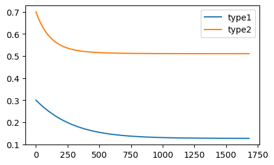

```python
plt.figure(figsize=(5, 3))
plt.plot(np.arange(s.shape[0]), s[:, 0], label='type1')
plt.plot(np.arange(s.shape[0]), s[:, 1], label='type2')
plt.legend()
plt.show()
```

## Objective: Steady State Rate of Booking

- What we care in the market is optimizing the rate of booking at the steady state $s^*$, induced by the matching technology that we have.
- Any matching technology and intervention will essentially be affecting the matching matrix $P = (P_{ij})_{i\in [n], j\in [m]}$.
- Any such matching technology $P$ will induce a steady state $s^*$.
- At this steady state, an arriving customer of type $i$ books at a rate of $\sum_j \pi_{ij}(s^*)$.
- Thus the overall rate of booking will be given as: \begin{align} Q = \mu \sum_{i} \phi_i \sum_j \pi_{ij}(s^*) \end{align}

```python
def rate_of_booking(s, P, epsilon, mu, phi):
    probs = P * s.reshape(1, -1)
    probs = probs / (epsilon + probs.sum(axis=1)).reshape(-1, 1)
    Q = mu * (phi @ probs @ np.ones(probs.shape[1]))
    return Q
```

Now we can calculate the rate of booking at steady state:

```python
Qcontrol = rate_of_booking(s[-1], P, epsilon, mu, phi)
Qcontrol
```

```
0.18611934242549985
```

Roughly this means that in steady state 18% of listings get booked per unit of time.

## Global Treatment

- We want to understand how a new "matching" or other technology would change the steady state rate of booking.
- Every such technology can be viewed as changing the matrix $P$ that determines the matching propensity of each customer of type $i$ with a listing of type $j$ to some other matrix $\tilde{P}$.
- For instance, the treatment could be "*show a super-host badge, next to the listing image*".

```python
# the matrix P that determines choice probabilities under the new treatment
Ptilde = np.array([[.5, .95], [.95, .5], [.6, .9]])
```

We don't really know this matrix and therefore we want to run some experiment that will estimate the rate of booking change, if we were to deploy this new technology.

## Calculating True Global Treatment Effect via Simulation

- As a first let's calculate what would happen if we deploy a new technology with a matrix $\tilde{P}$ to the global market.
- This rate of booking is the global treatment rate of booking
- The difference between this rate of booking and the rate of booking under the original technology with matrix $P$, is the **Global Treatment Effect (GTE)**.

```python
# Global Treatment
s = dynamics(Ptilde, epsilon, taus, mu, rho, phi)
s[-1]
```

```
array([0.11576917, 0.48566679])
```

```python
Qtreatment = rate_of_booking(s[-1], Ptilde, epsilon, mu, phi)
Qtreatment
```

```
0.20844657147463896
```

Thus we see that around 20% of listings get booked per-unit of time, under the new technology.

```python
GTE = Qtreatment - Qcontrol
GTE
```

```
0.022327229049139113
```

And the GTE is 2%, i.e. we expect to see a 2% increase in the percentage of listings booked per-unit of time, if we release the new technology in the whole market.

## Two-Sided Experiment

- We don't really want to deploy the new treatment globally, without first having a sign that it is working better than the existing technology. For this we want to run an experiment.
- A Two-Sided Randomized Experiment (TSRE) randomizes both the customers and the listings.
- Each customer is assigned to treatment with probability $a_C$ and to control with probability $1-a_C$.
- Each listing is assigned to treatment with probability $a_L$ and to control with probability $1-a_L$.
- We use the new technology only when a customer in the treatment cohort is using the service and only for the listings that are in the treatment cohort.

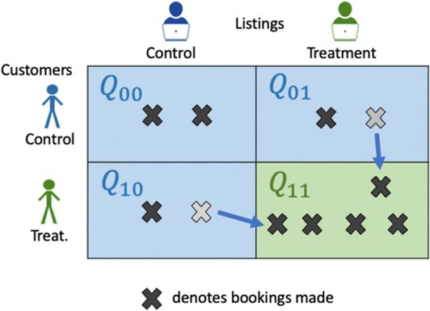

## Special Cases of TSRE: Customer or Listing Randomization

If $a_L=1$, then we are essentially only randomizing across customers, i.e. a customer in the treatment cohort sees the new technology applied to all listings (e.g. a treated customers sees all listings with the *super-host badge*).

If $a_C=1$, then we are essentially only randomizing across listings, i.e. all customers see the treatment listings with the technology being applied and all control listings with the technology not being applied (e.g. the treatment listings have the *super-host badge* whenever showcased to any customer and all control listings don't have the badge).

## Dynamics of Platform under TSRE

We can think of the system under the TSRE as a system with twice the types of customers and twice the types of listings. Now we have customer types $(i,0), (i,1)$ for $i\in \{1,\ldots,n\}$ and listing types $(j,0), (j,1)$, for $j\in \{1, \ldots, m\}$.

Customer type $(i,1)$ is a customer of type $i$ in the treatment cohort and customer type $(i,0)$ is a customer of type $i$ in the control cohort. Similarly for the listings.

The new technology is applied only for pairs $(i,1) \rightarrow (j,1)$, while for all other pairs of types, we are using the old technology. The matching matrix $P_e$ under the experiment is: \begin{align} P_e = \left(\begin{matrix} P & P\\ P & \tilde{P} \end{matrix}\right) \end{align} The arrival rate of a customer type is determined by the original arrival rate, times the customer randomization probability, i.e. \begin{align} \phi_{i,0} =~& \phi_i \cdot (1-a_C) & \phi_{i,1} =~& \phi_i \cdot a_C \end{align} The mass of listings is divided into the control and treatment listings: \begin{align} \rho_{j,0} =~& \rho_j \cdot (1 - a_L) & \rho_{j,1} =~& \rho_j \cdot a_L \end{align} Outside options $\epsilon$ of customers and replenishment rates $\tau$ of listings are not affected. \begin{align} \epsilon_{i,0}=~&\epsilon_{i,1} = \epsilon_i & \tau_{i,0} =~& \tau_{j,1} = \tau_j \end{align}

```python
def get_experiment_params(aC, aL, Ptilde, P, epsilon, taus, mu, rho, phi):
    # We create two copies of each customer and two copies of each listing
    # only (treated, treated) receive the new technology matching probs
    P_exp = np.block([[P, P], [P, Ptilde]])
    # outside option values
    epsilon_exp = np.block([epsilon, epsilon])
    # listing occupancy rates
    taus_exp = np.block([taus, taus])
    # listing distribution
    rho_exp = np.block([(1 - aL) * rho, aL * rho])
    # customer arrival distribution
    phi_exp = np.block([(1 - aC) * phi, aC * phi])
    return P_exp, epsilon_exp, taus_exp, mu, rho_exp, phi_exp
```

```python
# experiment share
aC = .5
aL = .5
params_exp = get_experiment_params(aC, aL, Ptilde, P, epsilon,
                                   taus, mu, rho, phi)
P_exp, epsilon_exp, taus_exp, mu, rho_exp, phi_exp = params_exp
```

## Experiment Steady State

If we let the experiment run for a sufficient time, it will also arrive at some steady state available listing distribution $s_e^*$, which corresponds to the steady state if we simulate the same dynamics but with the augmented system parameters defined above.

We can now simulate the system under TSRE and find the steady state:

```python
s = dynamics(P_exp, epsilon_exp, taus_exp, mu, rho_exp, phi_exp)
s[-1]
```

```
array([0.06707132, 0.25730263, 0.05838639, 0.2458206 ])
```

```python
Qexp = rate_of_booking(s[-1], P_exp, epsilon_exp, mu, phi_exp)
Qexp
```

```
0.19259505764396057
```

Thus under the TSRE we see that across the market we have 19% of bookings per unit of time.

## Decomposing Rate of Booking Across Cohorts

However, these bookings come from both treated and untreated pairs. To understand the treatment effect, we want to separate the rate of booking into rate of booking across the different treatment cohorts (either customers or listings).

Thus we will estimate the matrix \begin{align} Q = \left(\begin{matrix} Q_{00} & Q_{01}\\ Q_{10} & Q_{11} \end{matrix}\right) \end{align} where $Q_{dz}$ is the rate of booking of listings in cohort $z\in \{0,1\}$ from customers in cohort $d\in \{0,1\}$.

If we let $s_e^*$ the steady state of the platform under TSRE, then: \begin{align} Q_{dz} = \mu \sum_{i} \phi_{(i,d)} \sum_{j} \pi_{(i,d),(j,z)}(s_e^*) \end{align}

```python
def rate_of_booking_exp(s, P, epsilon, mu, phi):
    probs = P * s.reshape(1, -1)
    probs = probs / (epsilon + probs.sum(axis=1)).reshape(-1, 1)
    Q = np.zeros((2, 2))
    n_c = P.shape[0] // 2
    n_l = P.shape[1] // 2
    for i in range(2):
        for j in range(2):
            phi_i = phi[i * n_c : (i+1) * n_c]
            probs_ij = probs[i * n_c : (i+1) * n_c, j * n_l : (j+1) * n_l]
            Q[i, j] = mu * (phi_i @ probs_ij @ np.ones(probs_ij.shape[1]))
    return Q
```

```python
Q = rate_of_booking_exp(s[-1], P_exp, epsilon_exp, mu, phi_exp)
Q
```

```
array([[0.04774355, 0.04483103],
       [0.04311152, 0.05690896]])
```

## Interpreting the Numbers

Thus we see that we find $\approx$4.8% of the control listings are booked by control customers per-unit of time, $\approx$4.5% of treatment listings are booked by control customers, $\approx$4.3% of control listings are booked by treated customers and $\approx$5.7% of treated listings are booked by treated customers.

Note that if there was no interference, then the first three numbers should have all been identical, since the new technology was not used for these pairs of customer and listing types! Thus the small variations that we see in these three numbers are primarily due to interference!

## Signs of Interference

For instance, we see that we find fewer bookings among treated listings and control customers. The reason for this is that some of these listings are also showcased to treated customers and when so, the new technology is used (e.g. they are shown with the *super-host badge*). Thus such listings are less available in the market, because they are booked at higher rates by the treated customers and take time to replenish and come back to market. The control listings never have this problem, as they are shown without the technology to all customers. Hence, we see a 4.5% for treated listings as opposed to a 4.8% for control listings.

Similarly, the control listings receive fewer bookings from treated customers. The reason is that such treated customers see both treated and untreated listings when the visit (e.g. they see some listings with the *super-host badge* and some listings without). Assuming that the treatment increase the rate of booking, then these untreated listings are cannibalized by the treated listings. Thus we see a rate of booking of 4.3% from treated customers, as opposed to 4.8% from control customers.

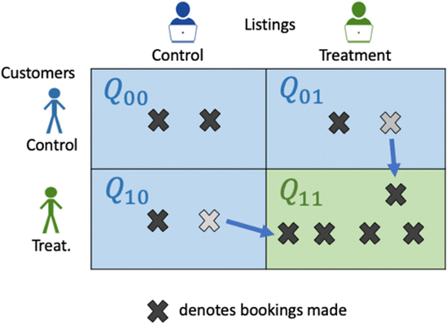

## Naive GTE Estimate

We can use these rates of booking to measure the GTE of the new technology.

Since only treated customer and treated listing pairs receive the treatment, we should use the "re-normalized" rate of booking on these sub-population as what we should expect to happen if we rolled out the new technology to everyone. Of course we need to divide by the mass of these cohorts to renormalize, i.e. $$\frac{Q_{11}}{a_C \cdot a_L}$$

Similary, since all other pairs don't receive the treatment, we can use the observed rate of booking among those cohorts, normalized by their mass, as what we would expect would happen under global control: $$\frac{Q_{01} + Q_{10} + Q_{00}}{1 - a_C \cdot a_L}$$

Then the naive GTE estimate under the TSRE is: \begin{align} \text{GTE}_{\text{TSR}} = \frac{Q_{11}}{a_C \cdot a_L} - \frac{Q_{01} + Q_{10} + Q_{00}}{1 - a_C \cdot a_L} \end{align}

```python
GTE_TSR = Q[1, 1] / (aC * aL) - (Q[0, 1] + Q[1, 0] + Q[0, 0]) / (1 - aC * aL)
GTE_TSR
```

```
0.04672101962253697
```

This naive estimate of the GTE is $\approx$4.7%!This is heavily biased, compared to the true value of $\approx$2.2%!

```python
Qtreatment - Qcontrol
```

```
0.022327229049139113
```

## Packaging The Analysis

```python
def bias_analysis(aC, aL, Ptilde, P, epsilon, taus, mu, rho, phi):
    # Global control
    s = dynamics(P, epsilon, taus, mu, rho, phi)
    Qcontrol = rate_of_booking(s[-1], P, epsilon, mu, phi)
    # Global Treatment
    s = dynamics(Ptilde, epsilon, taus, mu, rho, phi)
    Qtreatment = rate_of_booking(s[-1], Ptilde, epsilon, mu, phi)
    # Two-Sided Randomization Experiment
    params_exp = get_experiment_params(aC, aL, Ptilde, P, epsilon,
                                       taus, mu, rho, phi)
    P_exp, epsilon_exp, taus_exp, mu, rho_exp, phi_exp = params_exp
    s = dynamics(P_exp, epsilon_exp, taus_exp, mu, rho_exp, phi_exp)
    Q = rate_of_booking_exp(s[-1], P_exp, epsilon_exp, mu, phi_exp)
    GTE_TSR = Q[1, 1] / (aC * aL)
    GTE_TSR -= (Q[0, 1] + Q[1, 0] + Q[0, 0]) / (1 - aC * aL)
    return Q, Qcontrol, Qtreatment, GTE_TSR, Qtreatment - Qcontrol
```

```python
Qexp, Qc, Qt, GTE_TSR, GTE_true = bias_analysis(aC, aL, Ptilde, P, epsilon,
                                                taus, mu, rho, phi)
print(f"GTE_TSR={GTE_TSR:.4f}, GTE_True={GTE_true:.4f}")
```

```
GTE_TSR=0.0467, GTE_True=0.0223
```

# Demand Constrained Markets

Listings are replenished immediately, buy buyers arrive relatively infrequently

```python
taus = np.array([10.0, 10.0])
mu = 0.3
# experiment share
aC = .5
aL = .5
```

Two-sided randomization is still biased

```python
Qexp, Qc, Qt, GTE_TSR, GTE_true = bias_analysis(aC, aL, Ptilde, P, epsilon,
                                                taus, mu, rho, phi)
print(f"GTE_TSR={GTE_TSR:.4f}, GTE_True={GTE_true:.4f}")
```

```
GTE_TSR=0.0594, GTE_True=0.0206
```

But if we only do customer randomization, then we get the correct answer! In some sense the fact that treated listings are booked more frequently by other customers, does not introduce interference, as these listings are replenished immediately and are immediately available to other customers that arrive.

```python
# Only Customer Randomization
Qexp, Qc, Qt, GTE_TSR, GTE_true = bias_analysis(aC, 1.0, Ptilde, P, epsilon,
                                                taus, mu, rho, phi)
print(f"GTE_CR={GTE_TSR:.4f}, GTE_True={GTE_true:.4f}")
```

```
GTE_CR=0.0207, GTE_True=0.0206
```

Listing randomization is terrible, since now customers see both treated and un-treated listings in the same visit and hence the un-treated listings will be cannibalized by the treated listings.

```python
# Only Listing Randomization
Qexp, Qc, Qt, GTE_TSR, GTE_true = bias_analysis(1.0, aL, Ptilde, P, epsilon,
                                                taus, mu, rho, phi)
print(f"GTE_LR={GTE_TSR:.4f}, GTE_True={GTE_true:.4f}")
```

```
GTE_LR=0.0763, GTE_True=0.0206
```

# Supply Constraint Markets

Listings are very infrequently replenished, and customers arrive very frequently.

```python
taus = np.array([.2, .8])
mu = 10.0
# experiment share
aC = .5
aL = .5
```

Two-sided randomization is biased

```python
Qexp, Qc, Qt, GTE_TSR, GTE_true = bias_analysis(aC, aL, Ptilde, P, epsilon,
                                                taus, mu, rho, phi)
print(f"GTE_TSR={GTE_TSR:.4f}, GTE_True={GTE_true:.4f}")
```

```
GTE_TSR=0.1128, GTE_True=0.0037
```

Customer randomization is also biased, since now the customers arrive so frequently, that listings are replenished too infrequently. Hence, now the fact that other customers book treated listings, makes these listings unavailable for the un-treated customers and introduces interference.

```python
# Only Customer Randomization
Qexp, Qc, Qt, GTE_TSR, GTE_true = bias_analysis(aC, 1.0, Ptilde, P, epsilon,
                                                taus, mu, rho, phi)
print(f"GTE_CR={GTE_TSR:.4f}, GTE_True={GTE_true:.4f}")
```

```
GTE_CR=0.1626, GTE_True=0.0037
```

Listing randomization on the other hand is correct! The reason is that now listings are very infrequently available. Hence, whenever it becomes available, its rate of matching is not so much affected by the fact that other listings are treated. Thinking the extreme, a customer will basically only be seeing one listing option whenever they arrive (due to very slow replenishment) and that listing will either be treated or un-treated. Hence, there wont be much cannibalization across treated and un-treated listings, in the same user visit.

```python
# Only Listing Randomization
Qexp, Qc, Qt, GTE_TSR, GTE_true = bias_analysis(1.0, aL, Ptilde, P, epsilon,
                                                taus, mu, rho, phi)
print(f"GTE_LR={GTE_TSR:.4f}, GTE_True={GTE_true:.4f}")
```

```
GTE_LR=0.0035, GTE_True=0.0037
```

# Bias as we Interpolate between Customer vs Listing Randomization

Fixing the setting, TSR allows us to interpolate between either listing or customer randomization.

```python
# listing occupancy rates
taus = np.array([.2, .8])
# customer arrival rate
mu = .3
```

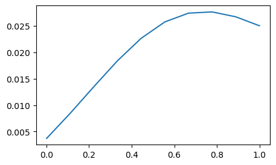

```python
bias = []
for aC in np.linspace(0.001, .999, 10):
    aL = 1 - aC
    Qexp, Qc, Qt, GTE_TSR, GTE_true = bias_analysis(aC, aL, Ptilde, P, epsilon,
                                                    taus, mu, rho, phi)
    bias.append(GTE_TSR - GTE_true)
plt.figure(figsize=(5, 3))
plt.plot(np.linspace(0.001, .999, 10), bias)
plt.show()
```

# Other Estimation Variants

- The TSRE design allows us to construct many other estimates
- We can compare only diagonal rates, i.e. purely treated vs pure untreated \begin{align} \text{GTE}_{\text{diag}} = \frac{Q_{11}}{a_C\cdot a_L} - \frac{Q_{00}}{(1-a_C)\cdot (1 -a_L)} \end{align}
- We can simulate an Customer Randomization estimate \begin{align} \text{GTE}_{\text{CR}} = \frac{Q_{11}}{a_C\cdot a_L} - \frac{Q_{01}}{(1-a_C)\cdot a_L} \end{align}
- We can simulate a Listing Randomization estimate \begin{align} \text{GTE}_{\text{LR}} = \frac{Q_{11}}{a_C\cdot a_L} - \frac{Q_{10}}{a_C\cdot (1 -a_L)} \end{align}
- We can consider a convex combinations of the above, with the convex combination dependent on whether we believe we are in a supply or demand constrained market \begin{align} \text{GTE}_{\beta} = \beta\cdot \text{GTE}_{\text{CR}} + (1-\beta)\cdot \text{GTE}_{\text{LR}} \end{align}

```python
bias, bias_CR, bias_LR = [], [], []
bias_mixed = []
bias_diag = []
beta = .4
kappa1, kappa2 = 1.0, 2.0
grid = np.linspace(0.001, .999, 20)
for aC in grid:
    aL = 1 - aC
    Q, Qc, Qt, GTE_TSR, GTE_true = bias_analysis(aC, aL, Ptilde, P, epsilon,
                                                 taus, mu, rho, phi)
    GTE_diag = Q[1, 1] / (aC*aL) - Q[0, 0] / ((1-aC)*(1-aL))
    GTE_CR = Q[1, 1] / (aC*aL) - Q[0, 1] / ((1-aC)*aL)
    GTE_LR = Q[1, 1] / (aC*aL) - Q[1, 0] / (aC*(1-aL))
    GTE_mixed = beta * GTE_CR + (1 - beta) * GTE_LR

    bias.append(np.abs(GTE_TSR - GTE_true))
    bias_diag.append(np.abs(GTE_diag - GTE_true))
    bias_CR.append(np.abs(GTE_CR - GTE_true))
    bias_LR.append(np.abs(GTE_LR - GTE_true))
    bias_mixed.append(np.abs(GTE_mixed - GTE_true))
```

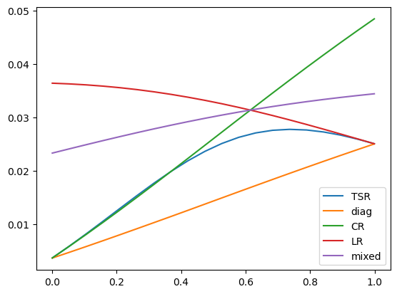

```python
plt.plot(grid, bias, label='TSR')
plt.plot(grid, bias_diag, label='diag')
plt.plot(grid, bias_CR, label='CR')
plt.plot(grid, bias_LR, label='LR')
plt.plot(grid, bias_mixed, label='mixed')
plt.legend()
plt.show()
```

# Debiasing Corrections

We can also use the differences that should have been zero under no interference, as signs of bias and add them to the estimate to correct the interference bias: \begin{align} \text{Bias}_1 =~& \frac{Q_{01}}{(1-a_C)\cdot a_L} - \frac{Q_{00}}{(1-a_C)\cdot (1-a_L)}\\ \text{Bias}_2 =~& \frac{Q_{10}}{a_C\cdot (1-a_L)} - \frac{Q_{00}}{(1-a_C)\cdot (1-a_L)} \end{align} And then we can add these correction terms to the mixed estimate with some weight: \begin{align} \text{GTE}_{\beta,\kappa} = \text{GTE}_{\beta} + \kappa\cdot \beta \cdot (1-\beta) \cdot (\text{Bias}_1 + \text{Bias}_2) \end{align}

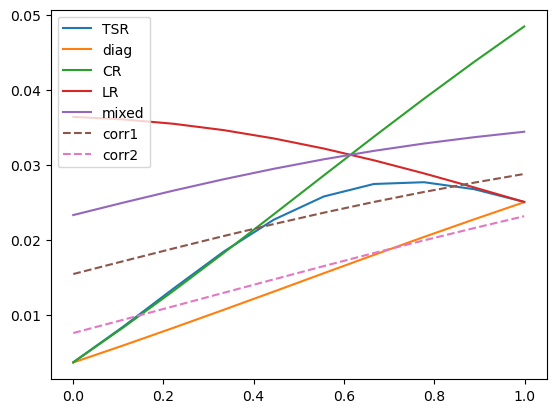

```python
plt.plot(grid, bias, label='TSR')
plt.plot(grid, bias_diag, label='diag')
plt.plot(grid, bias_CR, label='CR')
plt.plot(grid, bias_LR, label='LR')
plt.plot(grid, bias_mixed, label='mixed')
plt.plot(grid, bias_corr1, '--', label='corr1')
plt.plot(grid, bias_corr2, '--', label='corr2')
plt.legend()
plt.show()
```

[output not shown]

```python
# listing occupancy rates
taus = np.array([.2, .8])
# customer arrival rate
mu = 1.0
```

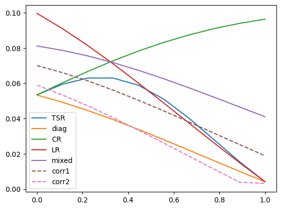

```python
plt.plot(grid, bias, label='TSR')
plt.plot(grid, bias_diag, label='diag')
plt.plot(grid, bias_CR, label='CR')
plt.plot(grid, bias_LR, label='LR')
plt.plot(grid, bias_mixed, label='mixed')
plt.plot(grid, bias_corr1, '--', label='corr1')
plt.plot(grid, bias_corr2, '--', label='corr2')
plt.legend()
plt.show()
```

[output not shown]